# easyROC: An Interactive Web-tool for ROC Curve Analysis Using R Language Environment

ROC curve analysis is a fundamental tool for evaluating the performance of a marker in a number of research areas, e.g., biomedicine, bioinformatics, engineering etc., and is frequently used for discriminating cases from controls. There are a number of analysis tools which are used to guide researchers through their analysis. Some of these tools are commercial and provide basic methods for ROC curve analysis while others offer advanced analysis techniques and a command-based user interface, such as the R environment. The R environmentg includes comprehensive tools for ROC curve analysis; however, using a command-based interface might be challenging and time consuming when a quick evaluation is desired; especially for non-R users, physicians etc. Hence, a quick, comprehensive, free and easy-to-use analysis tool is required. For this purpose, we developed a user-friendly web-tool based on the R language. This tool provides ROC statistics, graphical tools, optimal cutpoint calculation, comparison of several markers, and sample size estimation to support researchers in their decisions without writing R codes. easyROC can be used via any device with an internet connection independently of the operating system. The web interface of easyROC is constructed with the R package *shiny*. This tool is freely available through www.biosoft.hacettepe.edu.tr/easyROC.

Dincer Goksuluk (Department of Biostatistics, School of Medicine, Hacettepe University) , Selcuk Korkmaz (Department of Biostatistics, School of Medicine, Hacettepe University) , Gokmen Zararsiz (Department of Biostatistics, School of Medicine, Erciyes University) , A. Ergun Karaagaoglu (Department of Biostatistics, School of Medicine, Hacettepe University)  
2016-12-23

## 1 Introduction

The receiver operating characteristics (ROC) curve is a graphical approach used to visualize and assess the performance of a binary classifier system. This unique feature of ROC curve analysis makes it one of the most extensively used methods in various fields of science. It was originally developed during World War II to detect whether a signal on the radar screen represented an object or a noise (Egan 1975; Swets et al. 2000; Fan et al. 2006) and today it is widely used in medicine, radiology, biometrics, bioinformatics and various applications of machine learning and data mining research (Fawcett 2006; Sonego et al. 2008). ROC curve analysis can be implemented for several reasons: (i) to assess the overall performance of a classifier using several performance measures, (ii) to compare the performances of classifiers, and (iii) to determine the optimal cutpoint for a given classifier, diagnostic test or marker/biomarker. For simplicity of language, we will use the terms classifier and diagnostic test throughout the manuscript. The performance of a classifier can be summarized using the point estimations and confidence intervals of several basic performance measures such as sensitivity, specificity or combined measures of sensitivity and specificity such as likelihood ratios, accuracy, area under the ROC curve (AUC), etc. A ROC curve is basically a plot of a classifier’s true positive rates (TPR: sensitivity) versus false positive rates (FPR: $1 - \text{specificity}$) where each point is generated by a different threshold value, i.e., cutpoint. For the simplicity of equations, we will use the terms TPR and FPR in the equations. One of the major tasks is to determine the optimum cutpoint value which corresponds to the reasonable TPR and FPR values. The determination of an optimum value is usually a trade-off between performance measures. The ROC curve is used to find the optimal cutpoint located on the curve which is the closest point to the top-left corner. However, finding the “optimum” cutpoint is not always based on maximizing the sensitivity and specificity. It is reasonable to select an optimum cutpoint value by regarding alternative selection criteria such as maximization of predictive values, diagnostic odds ratio, etc.

There are a number of commercial (e.g., IBM SPSS, MedCalc, Stata, etc.) and open-source (R) software packages which are used to guide researchers through their ROC curve analysis. Some of these software packages provide basic features for ROC curve analysis while others, such as R, offer advanced features but also a command-based user interface. The R environment includes comprehensive tools for ROC curve analysis, such as [*ROCR*](https://CRAN.R-project.org/package=ROCR) (Sing et al. 2005), [*pROC*](https://CRAN.R-project.org/package=pROC) (Robin et al. 2011), [*ROC*](https://www.bioconductor.org/packages/release/bioc/html/ROC.html) (Carey and Redestig 2015) and [*OptimalCutpoints*](https://CRAN.R-project.org/package=OptimalCutpoints) (Lopez-Raton et al. 2014).

All of the R packages mentioned above perform ROC curve analysis using the related package functions. Although these packages are comprehensive and flexible, they require a good programming knowledge of the R language. However, working with a command-based interface might be challenging and time consuming when a quick evaluation is desired especially for non-R users, such as physicians and other health care professionalists. Fortunately, an R package [*shiny*](https://CRAN.R-project.org/package=shiny) (Chang, J. Cheng, J. Allaire, Y. Xie, and J. McPherson 2015) allows users to create interactive web-tools with a nicely designed, user-friendly and easy-to-use user interface. In this context, we developed a web-tool, easyROC, for ROC curve analysis. The user interface of easyROC is constructed via *shiny* and HTML codes. easyROC combines several R packages for ROC curve analysis. This tool has three main parts including ROC statistics, cutpoint calculations and sample size estimation. Detailed information about easyROC and the related methods together with mathematical background are given in Section 2. easyROC is freely available at http://www.biosoft.hacettepe.edu.tr/easyROC and all the source codes are on GitHub[^1].

## 2 Material and methods

### 2.1 Theory behind ROC analysis

Let us consider the binary classification problem where $X$ denotes the value of the classifier for cases and controls. Consider the values of controls distributed as $X_0 \sim G_0(.)$ and cases as $X_1 \sim G_1(.)$. Let $\hat{Y} = \{0,1\}$ be the estimated class labels of the subjects for a given threshold value $c$ as given in Equation (1).
$$\label{eqn:yhat}
\hat{Y} = \begin{cases}
1, & \quad \text{if} \ \ \ X \geq c \\
0, & \quad \text{if} \ \ \ X < c
\end{cases} \tag{1}$$

##### Parametric ROC curve.

The parametric ROC curve is plotted using the FPR ($1 - \mathrm{Specificity}$) and TPR ($\mathrm{Sensitivity}$) values given in Equation (2) for all possible cutpoints of a classifier.

$$\begin{aligned}
\label{eqn:fprtpr}
FPR_c =& P\left( X \geq c \; \vert \; Y = 0\right) = \int_{c}^{\infty}G_0(x)dx \nonumber \\
TPR_c =& P\left( X \geq c \; \vert \; Y = 1\right) = \int_{c}^{\infty}G_1(x)dx
\end{aligned} \tag{2}$$

When the distribution of the classifier is *Normal*, the parametric ROC curve is fitted using *binormal ROC* properties. Suppose $X_0 \sim Normal(\mu_0, \sigma_0^2)$ and $X_1 \sim Normal(\mu_1, \sigma_1^2)$. The ROC curve is the function of FPRs; as in Equation (3).

$$\label{eqn:rocPrmtrk}
ROC(t) = \Phi\left( a + b\Phi^{-1}\left( t \right)\right), \tag{3}$$

where $a = (\mu_1 - \mu_0)/\sigma_1$, $b = \sigma_0 / \sigma_1$, $t = FPR_c$ and $\Phi$ is the cumulative distribution function of the standard normal distribution (Zhou et al. 2002). The area under the curve is calculated using Equation (4).

$$\label{eqn:aucPrmtrk}
AUC = \int\limits_{0}^{1}ROC(t)dt = \Phi\left(\frac{a}{\sqrt{1 + b^2}}\right) \tag{4}$$

Fitting the ROC curve by using Equation (3) has two major drawbacks: (i) incorrect ROC curves may arise when the underlying distribution is not normal, (ii) ROC lines are improper when within class variations are not similar, i.e., heteroscedasticity. An example of improper ROC curves is given in Figure 1. To overcome these problems, one may nonparametrically fit the ROC curve without considering distributional assumptions or use parametric/semiparametric alternatives to the binormal model (Gönen and Heller 2010).

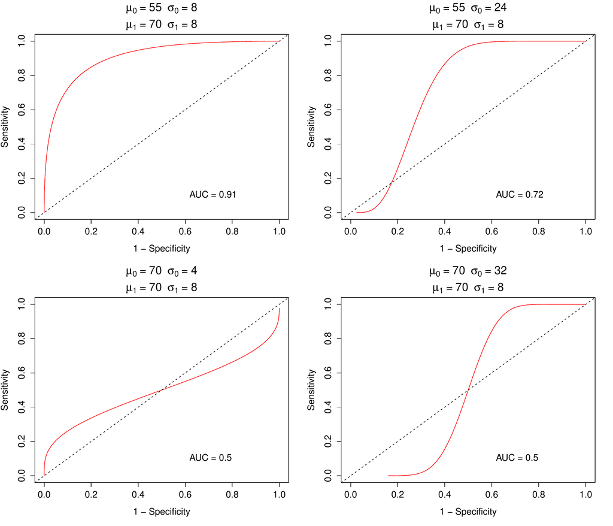

Figure 1: Parametric ROC curves.

##### Nonparametric ROC curve.

Consider the estimated class labels in Equation (1). The FPR and TPR given in Equation (2) are estimated; as given in Equation (5).

$$\begin{aligned}
\label{eqn:fprtprNP}
\widehat{FPR}_c =& \frac{1}{n_0}\sum\limits_{j=1}^{n_0}I\left[\; X_{0j} \geq c \;\right] \nonumber \\
\widehat{TPR}_c =& \frac{1}{n_1}\sum\limits_{i=1}^{n_1}I\left[\; X_{1i} \geq c \;\right]
\end{aligned} \tag{5}$$

The empirical ROC curve is plotted using $\widehat{FPR}_c$ and $\widehat{TPR}_c$ and the area under the curve, given in Equation (6), is estimated by summing the trapezoids enclosed by the points of the ROC curve. The nonparametric AUC is related to the Mann-Whitney statistic of the rank-sum test (Bamber 1975; Hanley and McNeil 1982).

$$\label{eqn:aucNP}
\widehat{AUC} = \frac{1}{n_0n_1}\sum\limits_{j = 1}^{n_0}\sum\limits_{i = 1}^{n_1}\Psi\left( X_{1i},X_{0j} \right), \tag{6}$$

where $\Psi = 0$ if $X_0 > X_1$, $\Psi = 1$ if $X_1 > X_0$ and $\Psi = 1/2$ if $X_0 = X_1$.

##### Performance measures and optimal cutpoints.

The predicted and actual classes, i.e., gold standard test results, can be shown with a $2 \times 2$ cross table; as seen in Table 1. The performance of a classifier is basically measured using the total proportion of true positive (TP) and true negative (TN) cases. By using Table 1, several performance measures are also calculated. Among these performance measures, we focused on the measures given in Table 1 which are widely used and well-known. The optimal cutpoint is determined by using one or more performance measures together. An ideal cutpoint, for example, might be selected by maximizing the sensitivity and specificity of a classifier. A classifier with perfect discriminative ability would have sensitivity and specificity measures equal to $1$. Hence, the area under the curve for a perfect separation will be equal to 1.

Table 1: A $2 \times 2$ classification table and performance measures.

[output not shown]

Although researchers are usually interested in the overall diagnostic performance of a classifier, it is sometimes useful to focus on a portion of the ROC curve to compute the partial AUCs (pAUC). pAUC is an extension of the AUC measure which considers the trapezoids within a given interval of sensitivity and/or specificity. Let us consider the pAUC where specificity (or sensitivity) lies within the interval $[t_1, t_2]$. The pAUC is calculated by taking the integral (parametric) as given in Equation (7) or by summing the trapezoids within the interval (nonparametric).

$$\label{eqn:paucPrmtrk}
pAUC(t_1, t_2) = \int\limits_{t_1}^{t_2}ROC(x)dx \tag{7}$$

As the interval $[t_1, t_2]$ converges to $[0, 1]$, the pAUC will converge to the overall AUC. The best classifier can be selected using either AUC or pAUC values.

Identification of the optimal cutpoint is an important task to avoid incorrect conclusions. Various methods are available in the literature to determine the optimal cutpoint. Most of these methods are based on the sensitivity and specificity measures. However, other methods are also available based on cost-benefit, prevalence, predictive values and diagnostic likelihood ratios. Two popular methods are, for example, the Youden index and the minimization of the distance of the point on the curve to the top-left corner, i.e., the point indicating perfect discrimination.

$$\label{eqn:youden}
\mathrm{Youden}(c) = \max\{TPR_c - FPR_c\} \tag{8}$$

##### Statistical inference.

A common subject of interest in ROC analysis is to compare the performances of several classifiers to select the best one to discriminate cases from controls. For a classifier with random chance discrimination ability, the equation $TPR = FPR$ holds. In that case, the area under the curve is $0.50$. Hence, the discrimination ability of a classifier is mostly tested against the value $0.50$.
$$\begin{aligned}
H_0 &: AUC = 0.50 \\
H_1 &: AUC \neq 0.50
\end{aligned}$$

Under the large sample theory, the significance of AUC is tested using the *Wald* test statistic as given in Equation (9).

$$\label{eqn:aucWald}
z = \frac{\widehat{AUC} - AUC}{\mathrm{Var}(\widehat{AUC})^{1/2}} \tag{9}$$

When the parametric approach is used, the variance of AUC is estimated using Equation (10) (McClish 1989; Zhou et al. 2002).

$$\label{eqn:varAUCparametric}
\mathrm{Var}\left( \widehat{AUC} \right) = f^2 \mathrm{Var}(\hat{a}) + g^2 \mathrm{Var}(\hat{b}) + 2fg\, \mathrm{Cov}(\hat{a}, \hat{b}), \tag{10}$$

where

$$\label{eqn:varAUCparametric_fg}
f = \frac{e^{-a^{2} / 2(1 + b^2)}}{\sqrt{2\pi(1 + b^2)}} \qquad \text{and} \qquad g = -\frac{abe^{-a / 2(1 + b^2)}}{\sqrt{2\pi(1 + b^2)^3}} \tag{11}$$

and the estimated variances for $a$ and $b$ as follows:

$$\begin{aligned}
\mathrm{\widehat{Var}}(\hat{a}) =& \frac{n_1 (\hat{a}^2 + 2) + 2n_0\hat{b}^2}{2n_0n_1}, \nonumber \\
\mathrm{\widehat{Var}}(\hat{b}) =& \frac{(n_1 + n_0)\hat{b}^2}{2n_0n_1}, \\
\mathrm{\widehat{Cov}}(\hat{a}, \hat{b}) =& \frac{\hat{a}\hat{b}}{2n_0}. \nonumber
\end{aligned}$$

The estimated values of $a$ and $b$ are used in Equation (11). A number of methods have been proposed for the estimation of the variance of AUC when the nonparametric approach is used. In this paper, we will focus on the methods described below:

1. Mann-Whitney version of rank-sum test:

   Hanley and McNeil (1982) propose the variance estimation given in Equation (12). This method estimates the variance using an approximation based on exponential distribution as

   $$\begin{aligned}
   \label{eqn:varAUC_MW}
   \mathrm{Var}\left( \widehat{AUC}\right) = \frac{1}{n_0n_1} & \left\lbrace AUC(1-AUC) + (n_1 - 1)(Q_1 - AUC^2) \right. \nonumber \\
   & \left. + (n_0 - 1)(Q_2 - AUC^2) \right\rbrace,
   \end{aligned} \tag{12}$$

   where $Q_1 = \widehat{AUC} / (2 - \widehat{AUC})$ and $Q_2 = 2\widehat{AUC}^2 / (1 + \widehat{AUC})$. The Mann-Whitney version might underestimate the variance when the area is nearly 0.5 and overestimate it when the area is close to 1 (Hanley and McNeil 1982; Obuchowski 1994; Hanley and Hajian-Tilaki 1997). This estimate is mostly used in sample-size estimation.
2. DeLong et al. (1988)’s estimate:

   Since the exponential distribution approximation in Equation (12) gives biased variance estimates, DeLong et al. (1988) suggest an alternative method which is free from distributional assumptions. Define the components $T_{1i}$ for the $i$th subject from cases and $T_{0j}$ for the $j$th subject from controls as follows:

   $$\begin{aligned}
   \label{eqn:varDeLongComponents}
   \psi\left( T_{1i} \right) =& \frac{1}{n_0}\sum\limits_{j=1}^{n_0} \Psi \left( X_{1i}, X_{0j}\right) \qquad i = 1,2, \ldots ,n_1 \nonumber \\
   \psi\left( T_{0j} \right) =& \frac{1}{n_1}\sum\limits_{i=1}^{n_1} \Psi \left( X_{1i}, X_{0j}\right) \qquad j = 1,2, \ldots ,n_0
   \end{aligned} \tag{13}$$

   Using the Equation (13) the variance of AUC is estimated as

   $$\label{eqn:varDeLong}
   \mathrm{Var}\left( \widehat{AUC} \right) = \frac{1}{n_1}S_{T_1}^{2} + \frac{1}{n_0}S_{T_0}^{2}, \tag{14}$$

   where $S_{T_1}^{2}$ and $S_{T_0}^{2}$ are variance estimates of $T_{1}$ and $T_{0}$ as in Equation (15).

   $$\label{eqn:varianceEstimatesOfDeLongComponents}
   S_{T_i}^{2} = \frac{1}{n_i - 1} \sum\limits_{j = 1}^{n_i}\left[ \psi \left( T_{ij}\right) - \widehat{AUC}\right]^2 \qquad i = 0, 1 \tag{15}$$
3. Normal approximation of binomial proportion:

   Another alternative for variance estimation is to use binomial approximation under the large sample theory, as given in Equation (16). For small samples, this method may give biased estimates.

   $$\label{eqn:varAUC_binom}
   \mathrm{Var}(\widehat{AUC}) = \frac{AUC(1 - AUC)}{n_0 + n_1} \tag{16}$$

The estimated variance derived from one of the methods described above is used to construct the confidence intervals of the AUC. A common method is to use large sample approximation as below:

$$\label{eqn:ciAUC}
\widehat{AUC} - z_{1 - \alpha / 2}\mathrm{Var}(\widehat{AUC})^{1/2} < AUC < \widehat{AUC} + z_{1 - \alpha / 2}\mathrm{Var}(\widehat{AUC})^{1/2}. \tag{17}$$

When the area under the curve is close to 1 or the sample size is relatively small, the large sample approximation in Equation (17) produces improper confidence intervals since the upper limit exceeds 1. To solve this problem, Agresti and Coull (1998) proposed the *score confidence interval* that guarantees the upper limit is less than or equal to 1. Another alternative is to construct the binomial exact confidence intervals given in Equation (18) using the relationship between binomial and *F*-distribution (Morisette and Khorram 1998)

$$\label{eqn:ciExact}
\dfrac{1}{1 + \dfrac{n - x + 1}{x}F_{2(n - x + 1), 2x, \alpha / 2}} \leq p \leq \dfrac{\dfrac{x + 1}{n - x} F_{2(x + 1), 2(n - x), \alpha / 2}}{1 + \dfrac{x + 1}{n - x} F_{2(x + 1), 2(n - x), \alpha / 2}}, \tag{18}$$

where $p = x/n$ is the binomial proportion such as sensitivity, specificity and AUC.

##### Sample size calculation.

In most studies, determining the required sample size is an important step for the research to be able to detect significant results. Sample size determination is required for both constructing the confidence interval of the unknown population parameter and testing a research hypothesis. Obuchowski (1998) reviewed sample size determination for several study designs. In this paper, we cover the sample size determination for three types of studies based on AUCs. In addition, the following sample size calculations can be extended to other performance measures such as sensitivity, specificity, etc.

The variance estimates of AUCs can be obtained using one of the Equations (12), (14) and (16). While Equation (12) is a good approximation for a variety of underlying distributions, the estimated variance will be underestimated if the test results are in a discrete rating format. To overcome this problem, Obuchowski (1998) and Obuchowski et al. (2004) suggest an alternative variance estimation method for rating data using the variance function as given in Equation (19) which is based on an underlying binormal distribution. In this section, we focused on sample size calculation for discrete scale data. However, the same formulas are valid for continuous scale diagnostic tests since the only difference is about estimating the variance of diagnostic test accuracy.

$$\label{eqn:varAUC_SS1}
\mathrm{V}(\widehat{AUC}) =
0.0099\,e^{-a^2/2}\times\left[ (5a^2 + 8) + (a^2 + 8)/R \right], \tag{19}$$

where $a = \sqrt{2}\,\Phi^{-1}(AUC)$ and $R=n_0 / n_1$ is the allocation ratio, i.e., the ratio of the number of controls to the number of cases. The estimated variance is then $\mathrm{Var}(\widehat{AUC}) = \mathrm{V}(\widehat{AUC}) / n_1$. The total sample size is equal to $n = n_1(1+R)$. One of the variance estimations from Equations (12), (14), (16) and (19) is used for the sample size calculations. The selection of the appropriate variance estimation method is based on the variable type of the test results and underlying distributions.

1. Hypothesis test to determine the AUC of a single classifier:

   In most of the studies with a single classifier, the aim of the study is to determine whether the diagnostic test performs well for discriminating diseased patients from controls. Consider the hypotheses $H_0: AUC = 0.5$ versus $H_1: AUC > 0.5$ (i.e, one-sided test). The required number of cases is determined using Equation (20) (Obuchowski et al. 2004).

   $$\begin{aligned}
   \label{eqn:aucSS_1}
   n_1 &= \dfrac{\left[ z_{1-\alpha} \sqrt{\mathrm{Var}_0(\widehat{AUC})} + z_{1-\beta} \sqrt{\mathrm{Var}_1(\widehat{AUC})}\,\right]^2}{\left(AUC - 0.5\right)^2} \nonumber \\
   &= \dfrac{\left[ z_{1-\alpha} \sqrt{0.0792\times(1 + 1/R)} + z_{1-\beta} \sqrt{\mathrm{Var}_1(\widehat{AUC})}\right]^2}{\left(AUC - 0.5\right)^2},
   \end{aligned} \tag{20}$$

   where $\mathrm{Var}_0$ and $\mathrm{Var}_1$ are the variance estimations under the null and alternative hypotheses using Equation (19). $z_{1-\alpha}$ and $z_{1-\beta}$ are lower-tailed percentile values of the cumulative standard normal distribution. Finally, the total sample size is obtained using $n = n_1 + n_1 \times R$.
2. Comparing the AUCs of two classifiers:

   When the aim of a study is to compare two classifiers, one may consider the hypotheses $H_0: AUC_1 = AUC_2$ versus $H_1: AUC_1 \neq AUC_2$. The two classifiers will be equally performing under the null hypothesis. The required number of cases is calculated using Equation (21).

   $$\label{eqn:SSauc2grp}
   n_1 = \dfrac{\left[ z_{1 - \alpha / 2} \sqrt{\mathrm{Var}_0 (\widehat{AUC_1} - \widehat{AUC_2})} + z_{1 - \beta} \sqrt{\mathrm{Var}_1 (\widehat{AUC_1} - \widehat{AUC_2})} \right]^2}{(AUC_1 - AUC_2)^2}, \tag{21}$$

   where $\mathrm{Var}_0$ and $\mathrm{Var}_1$ are the variance estimations under the null and alternative hypotheses; as given in Equation (22) (Zhou et al. 2002; Obuchowski et al. 2004).

   $$\begin{aligned}
   \label{eqn:var2auc}
   \mathrm{Var}(\widehat{AUC}_1 - \widehat{AUC}_2) &= \mathrm{Var}(\widehat{AUC}_1) + \mathrm{Var}(\widehat{AUC}_2)
   - 2\mathrm{Cov}(\widehat{AUC}_1, \widehat{AUC}_2)
   \end{aligned} \tag{22}$$

   The total sample size is calculated using the allocation ratio. When two classifiers are performed on the same subjects, the design will be *paired* yielding the covariance term to be a nonzero (usually positive) quantity. However, the covariance term will be zero (i.e., independent classifiers) if each test is performed on different subjects. Detailed information on the calculation of the covariance term can be found in Zhou et al. (2002).
3. Non-inferiority of a new classifier to a standard one:

   In addition to comparing two classifiers, some studies are designed to explore the performance of a new classifier to that of a standard one. The new classifier should perform as well as but not necessarily better than the standard test (Obuchowski et al. 2004). The hypotheses are $H_0: AUC_{std} - AUC_{new} \geq \Delta$ versus $H_1: AUC_{std} - AUC_{new} < \Delta$. The required number of cases is calculated using Equation (23)

   $$\label{eqn:SSaucNonInf}
   n_1 = \dfrac{(z_{1 - \alpha} + z_{1 - \beta})^2 \, \mathrm{Var}_1(\widehat{AUC}_{std} - \widehat{AUC}_{new})}{(AUC_{std} - AUC_{new} - \Delta)^2}, \tag{23}$$

   where $\Delta$ is the non-inferiority margin, i.e., the minimum acceptable difference between the AUCs of the standard and new classifiers.

### 2.2 Current ROC analysis tools and easyROC

Another R package worth mentioning is [*plotROC*](https://CRAN.R-project.org/package=plotROC) (Sachs 2016) which is available on CRAN and also for *shiny* platforms. *plotROC* is a flexible and sophisticated R package which can be used to create nice-looking and interactive ROC graphs. Unlike the packages described above, *plotROC* has a web-based user interface which is very useful for non-R users. Researchers can use its web service to create ROC graphics and download the figures to their local computer. However, it does not provide any statistical tests or sample size calculations.

Table 2: Comparison of easyROC with other tools.

|  | IBM SPSS | Stata | MedCalc | ROC | ROCR | pROC | easyROC |
| --- | --- | --- | --- | --- | --- | --- | --- |
| Plots | Yes | Yes | Yes* | Yes | Yes* | Yes* | Yes* |
| Conf. intervals | Yes | Yes* | Yes | Yes | Yes | Yes* | Yes* |
| pAUC | No | Yes | No | Yes | Yes | Yes* | Yes* |
| Statistical tests | No | Yes | No | Yes | Yes | Yes* | Yes* |
| Diagnostic measures | No | Yes | Yes | No | Yes* | Yes | Yes |
| Multiple comp. | No | Yes | Yes* | No | No | Yes* | Yes |
| Cutpoints | No | Yes | Yes | No | No | Yes | Yes* |
| Sample size | No | No | Yes | No | No | Yes | Yes* |
| Free license | No | No | No | Yes* | Yes* | Yes* | Yes* |
| Open source | No | No | No | Yes* | Yes* | Yes* | Yes* |
| Web-tool access | No | No | No | No | No | No | Yes* |
| User interface | Yes | Yes* | Yes* | No | No | Yes* | Yes* |
| * Comprehensive ones. |  |  |  |  |  |  |  |

easyROC aims to extend the features of several ROC packages in R and allows researchers to conduct their ROC curve analysis through a single and easy-to-use interface without writing any R code. This tool is a web-based application created via *shiny* and HTML programming. easyROC makes use of the R packages [*plyr*](https://CRAN.R-project.org/package=plyr) (Wickham 2011), *pROC* and *OptimalCutpoints* for conducting ROC analysis. *plyr* is used for manipulating data while *pROC* is used for estimation and hypothesis testing of pAUCs. easyROC has comprehensive options for ROC curve analysis which other tools do not have (or partially shares some features). The ROC curve can be estimated using parametric or nonparametric approaches. It offers four different methods for the calculation of the standard error and confidence interval of the AUC. Researchers can calculate the pAUCs based on sensitivity and specificity, if necessary. One may perform pairwise comparisons to find the classifiers which have similar or different discrimination ability. However, the pairwise comparison should be carried out carefully since the type I error increases with the increasing number of comparisons. easyROC offers multiple test corrections in order to keep type I error at a given level. Multiple comparisons of diagnostic tests can be applied using either Bonferroni or false discovery rate correction. Furthermore, the optimal cutpoints are determined using the methods from *OptimalCutpoints* and the corresponding measures at a given cutpoint, including sensitivity, specificity, positive and negative predictive values, and positive and negative likelihood ratios are also returned. One can determine the desired sample size for ROC curve analysis using this tool for three different cases. All these comprehensive features are accessible through a graphical user interface, which makes the analysis process easier for all users. The comparison with other tools is given in Table 2 and the features of each module are given in Table 3.

Table 3: Features of easyROC.

Modules (Tab panels)

Features

ROC curve

- Parametric/Nonparametric ROC
- AUC, pAUC
  - Confidence interval (Exact and Asymptotic)
  - Significance test (Wald)
- Standard error estimation
  - DeLong (1988)
  - Mann-Whitney
  - Binomial approximation
- Multiple comparison of AUCs
  - Bonferroni
  - False discovery rate
- ROC plot (customizable)

Cutpoints

- 34 different methods for optimum cutpoints (Lopez-Raton et al. 2014)
- Performance measures with confidence intervals
  - Exact CIs
  - Asymptotic CIs
- Cutpoint graphs (fully customizable)
  - ROC curve
  - Sensitivity & specificity plot
  - Density plot
  - Scatter plot

Sample size

- Single diagnostic test
- Comparison of two diagnostic tests
- Noninferiority of a new test to a standard test

## 3 Results

### 3.2 Implementation of easyROC web-tool

The data are uploaded to the easyROC interface using the *Data upload* tab (Figure 2). easyROC accepts a delimited text file with variable names in the first row. The status variable is also set by the same tab panel. easyROC automatically detects the variable names and exports them into related fields. When data are correctly uploaded, researchers may proceed with ROC curve analysis, cutpoint estimations or sample size calculations. The area under the curve, confidence intervals and significance tests for AUC, multiple comparisons (if multiple markers are selected) and pAUCs are calculated with the *ROC curve* tab (Figures 3 and 4). The ROC curve is estimated using the nonparametric approach. The advanced option allows researchers to select a method for standard error estimation and confidence intervals. easyROC selects the DeLong et al. (1988) method by default.

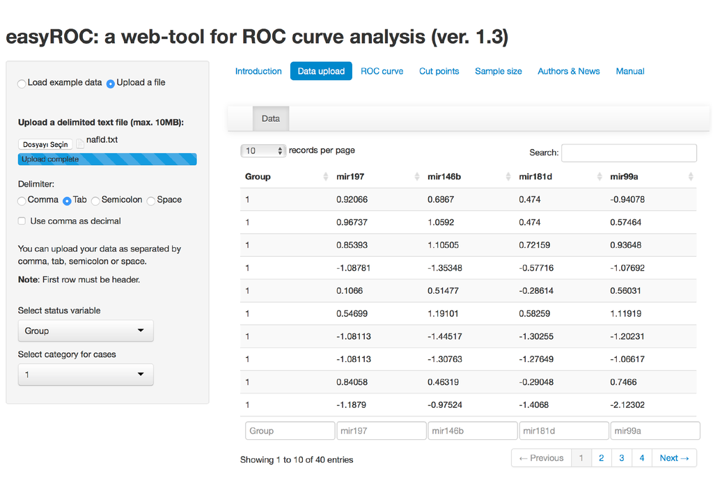

Figure 2: Uploading data into easyROC.

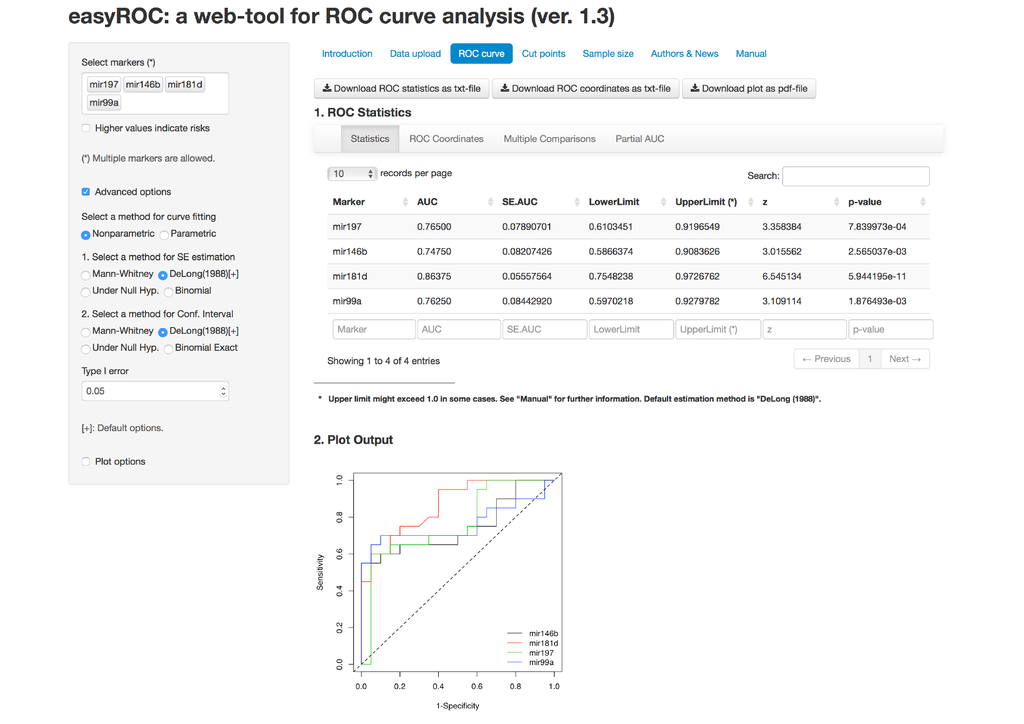

Figure 3: ROC curve analysis results.

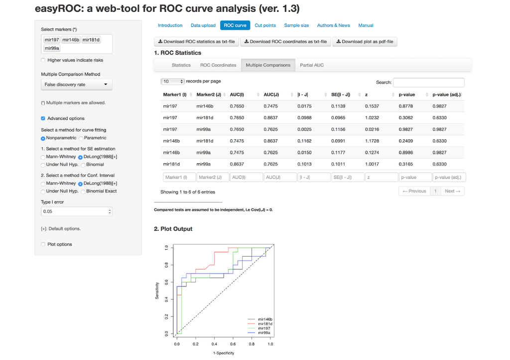

Figure 4: Multiple comparison of the diagnostic tests.

Finding a suitable cutpoint is one of the aims of ROC curve analysis. We made use of the *OptimalCutPoints* package from R (Lopez-Raton et al. 2014), which has 34 different methods, to calculate cutpoints for each marker. An optimal cutpoint can be computed via the *Cut point* tab by selecting a marker and a method. Then, the application will calculate an optimal cutpoint and performance measures such as sensitivity, specificity, positive and negative predictive value, and positive and negative likelihood ratio based on the corresponding cutpoint value. The “ROC01” method, for example, determines the optimal cutpoint as $-0.12977$ for mir181d. Using this cutpoint, a new test observation with a mir181d expression level lower than this value can be assigned as an NAFLD patient. Based on the identified cutpoint, we obtained statistical diagnostic measures with 95% confidence intervals (Figure 5). We obtain a sensitivity of $0.75$ (0.51–0.91) and specificity of $0.80$ (0.56–0.94). If users select the “Include plots” option, four plots will appear under the statistics results. The first plot in the upper-left corner displays the optimal cutpoint on the ROC curve. Users can observe the change of sensitivity and specificity measures based on the value of the marker on the plot placed in the upper-right corner. The density and scatter of the expression values in each group are displayed in the bottom-left and bottom-right corners. The plots can be modified through the “More plot options” section. All the results and figures can be downloaded using the related “Download” buttons in each tab panel.

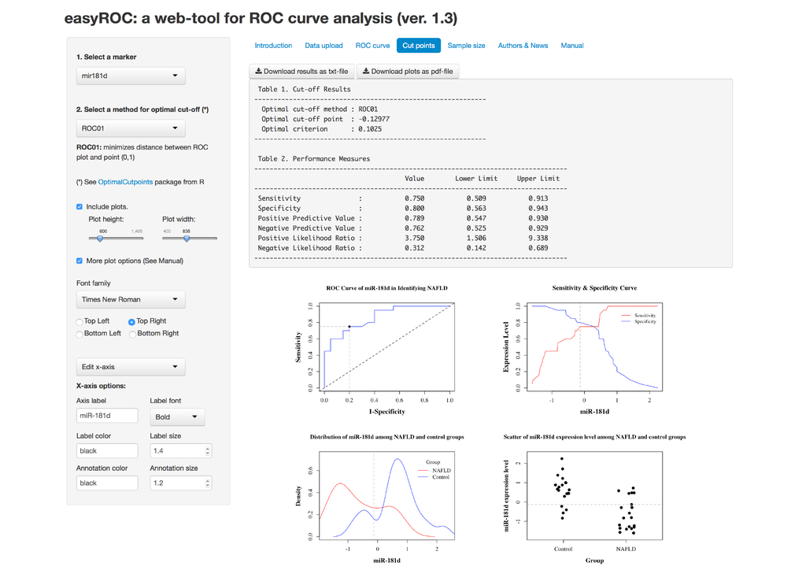

Figure 5: Determination of optimal cutpoint(s).

## 4 Conclusion

Since ROC curve analysis is one of the principal statistical analysis methods, it is used by a wide range of the scientific community. Both commercial and free software tools are available for users to perform it. Generally, easy-to-use and nicely-designed interfaces are offered by commercial software packages whereas flexible and comprehensive tools are available in free, open-access, code-based software packages, such as R. The first novelty of our tool is that it allows the user to use free and open-access software with an easy-to-use interface. In other words, we combine the power of an open-source and free language with a nicely designed and easily accessible interface. This tool offers more comprehensive features and a wide variety of implementations for ROC curve analysis than its commercial and free counterparts, which is another novelty of this application. It is specifically constructed for ROC curve analysis, unlike the commercial software packages, such as IBM SPSS, Stata and MedCalc.

This web-based application is intended for research purposes only, not for clinical or commercial use. Since it is a non-profit service to the scientific community, it comes with no warranty and no data security. However, since this web server uses the R package *shiny*, each user performs his/her analyses in a new R session. After uploading data, the application only saves responses within its R session and prints the results instantly. After a user has quit the application, the corresponding R session will be closed and any uploaded data, responses or outputs will not be saved locally or remotely.

This tool is freely available through http://www.biosoft.hacettepe.edu.tr/easyROC/ and all the source codes are available at http://www.github.com/dncR/easyROC under GPL version 3. It will be regularly updated upon the dependent R packages used in this application, including *shiny* and *OptimalCutpoints*, and new features will be continually added as they are developed.

## 5 Supplementary material

Supplement 1: A brief description of optimal cutpoint methods.

[output not shown]

Supplement 2: Non-alcoholic fatty liver disease NAFLD data Çelikbilek et al., 2014.

| **Grup** | **mir197** | **mir146b** | **mir181d** | **mir99a** |  | **Grup** | **mir197** | **mir146b** | **mir181d** | **mir99a** |
| --- | --- | --- | --- | --- | --- | --- | --- | --- | --- | --- |
| 1 | 0.921 | 0.687 | 0.474 | 0.941 |  | 0 | 1.214 | 1.122 | 0.882 | 1.610 |
| 1 | 0.967 | 1.059 | 0.474 | 0.575 |  | 0 | 1.401 | 0.148 | 0.444 | 0.625 |
| 1 | 0.854 | 1.105 | 0.722 | 0.936 |  | 0 | 0.494 | 0.179 | 1.386 | 0.134 |
| 1 | 1.088 | 1.353 | 0.577 | 1.077 |  | 0 | 1.608 | 1.386 | 2.242 | 0.926 |
| 1 | 0.107 | 0.515 | 0.286 | 0.560 |  | 0 | 1.274 | 1.609 | 0.769 | 1.108 |
| 1 | 0.547 | 1.191 | 0.583 | 1.119 |  | 0 | 0.827 | 1.128 | 0.452 | 0.374 |
| 1 | 1.081 | 1.445 | 1.303 | 1.202 |  | 0 | 0.147 | 0.545 | 0.878 | 0.044 |
| 1 | 1.081 | 1.308 | 1.276 | 1.066 |  | 0 | 0.353 | 0.320 | 0.225 | 0.367 |
| 1 | 0.841 | 0.463 | 0.290 | 0.747 |  | 0 | 1.635 | 0.677 | 0.838 | 0.543 |
| 1 | 1.188 | 0.975 | 1.407 | 2.123 |  | 0 | 1.848 | 1.523 | 1.712 | 0.940 |
| 1 | 1.014 | 0.649 | 1.194 | 1.786 |  | 0 | 0.987 | 0.606 | 0.626 | 0.542 |
| 1 | 1.081 | 1.256 | 1.229 | 0.679 |  | 0 | 0.020 | 0.503 | 0.600 | 0.367 |
| 1 | 1.295 | 1.204 | 1.607 | 2.216 |  | 0 | 1.061 | 1.518 | 1.217 | 0.209 |
| 1 | 1.081 | 1.268 | 0.829 | 0.658 |  | 0 | 0.474 | 0.572 | 0.292 | 0.786 |
| 1 | 1.081 | 1.365 | 1.376 | 1.457 |  | 0 | 0.868 | 0.505 | 0.408 | 0.117 |
| 1 | 1.081 | 1.371 | 0.812 | 1.804 |  | 0 | 0.414 | 0.259 | 0.665 | 0.363 |
| 1 | 1.081 | 0.769 | 1.359 | 0.156 |  | 0 | 0.394 | 0.417 | 1.000 | 0.130 |
| 1 | 0.854 | 1.243 | 0.444 | 1.460 |  | 0 | 0.941 | 0.543 | 0.431 | 1.083 |
| 1 | 1.074 | 1.365 | 1.572 | 0.339 |  | 0 | 0.387 | 0.202 | 0.568 | 0.345 |
| 1 | 0.634 | 0.276 | 0.130 | 0.081 |  | 0 | 0.674 | 0.689 | 0.995 | 0.893 |

### 5.1 CRAN packages used

ROCR, pROC, OptimalCutpoints, shiny, plotROC, plyr

### 5.2 CRAN Task Views implied by cited packages

MachineLearning, WebTechnologies

### 5.3 Bioconductor packages used

ROC

A. Agresti and B. A. Coull. Approximate is better than “exact” for interval estimation of binomial proportions. *The American Statistician*, 52(2): 119–126, 1998. DOI 10.2307/2685469.

D. Bamber. The area above the ordinal dominance graph and the area below the receiver operating characteristic graph. *Journal of Mathematical Psychology*, 12(4): 387–415, 1975. DOI 10.1016/0022-2496(75)90001-2.

V. Carey and H. Redestig. *ROC: Utilities for ROC, with uarray focus.* 2015. URL https://www.bioconductor.org. R package version 1.44.0.

M. Celikbilek, M. Baskol, S. Taheri, K. Deniz, S. Dogan, G. Zararsiz, S. Gursoy, K. Guven, O. Ozbakir, M. Dundar, et al. Circulating microRNAs in patients with non-alcoholic fatty liver disease. *World Journal of Hepatology*, 6(8): 613–620, 2014.

W. Chang, J. Cheng, J. Allaire, Y. Xie, and J. McPherson. *shiny: Web Application Framework for R, .* R package version 0.12.1, 2015. URL https://CRAN.R-project.org/package=shiny.

E. R. DeLong, D. M. DeLong and D. L. Clarke-Pearson. Comparing the areas under two or more correlated receiver operating characteristic curves: A nonparametric approach. *Biometrics*, 44(3): 837–845, 1988. DOI 10.2307/2531595.

J. P. Egan. *Signal detection theory and ROC analysis.* New York, NY: Academic Press, 1975.

J. Fan, S. Upadhye and A. Worster. Understanding receiver operating characteristic (ROC) curves. *Canadian Journal of Emergency Medicine*, 8: 19–20, 2006. DOI 10.1017/s1481803500013336.

T. Fawcett. An introduction to ROC analysis. *Pattern Recognition Letters*, 27(8): 861–874, 2006. DOI 10.1016/j.patrec.2005.10.010.

M. Gönen and G. Heller. Lehmann family of ROC curves. *Medical Decision Making*, 30(4): 509–517, 2010. DOI 10.1177/0272989x09360067.

J. A. Hanley and K. O. Hajian-Tilaki. Sampling variability of nonparametric estimates of the areas under receiver operating characteristic curves: An update. *Academic Radiology*, 4(1): 49–58, 1997. DOI 10.1016/s1076-6332(97)80161-4.

J. A. Hanley and B. J. McNeil. A method of comparing the areas under receiver operating characteristic curves derived from the same cases. *Radiology*, 148(3): 839–843, 1983. DOI 10.1148/radiology.148.3.6878708.

J. A. Hanley and B. J. McNeil. The meaning and use of the area under a receiver operating characteristic (ROC) curve. *Radiology*, 143(1): 29–36, 1982. DOI 10.1148/radiology.143.1.7063747.

M. Lopez-Raton, M. X. Rodriguez-Alvarez, C. Cadarso-Suárez and F. Gude-Sampedro. OptimalCutpoints: An R package for selecting optimal cutpoints in diagnostic tests. *Journal of Statistical Software*, 61(8): 1–36, 2014. DOI 10.18637/jss.v061.i08.

D. K. McClish. Analyzing a portion of the ROC curve. *Medical Decision Making*, 9(3): 190–195, 1989. DOI 10.1177/0272989x8900900307.

J. T. Morisette and S. Khorram. Exact binomial confidence interval for proportions. *Photogrammetric Engineering and Remote Sensing*, 64(4): 281–283, 1998.

P. A. Murtaugh, E. R. Dickson, G. M. Van Dam, M. Malinchoc, P. M. Grambsch, A. L. Langworthy and C. H. Gips. Primary biliary cirrhosis: Prediction of short-term survival based on repeated patient visits. *Hepatology*, 20(1): 126–134, 1994. DOI 10.1002/hep.1840200120.

N. A. Obuchowski. Computing sample size for receiver operating characteristic studies. *Investigative Radiology*, 29(2): 238–243, 1994. DOI 10.1097/00004424-199402000-00020.

N. A. Obuchowski. Sample size calculations in studies of test accuracy. *Statistical Methods in Medical Research*, 7(4): 371–392, 1998.

N. A. Obuchowski, M. L. Lieber and F. H. Wians. ROC curves in clinical chemistry: Uses, misuses, and possible solutions. *Clinical Chemistry*, 50(7): 1118–1125, 2004. DOI 10.1373/clinchem.2004.031823.

M. Pepe, G. Longton and H. Janes. Estimation and comparison of receiver operating characteristic curves. *The Stata Journal*, 9(1): 1, 2009.

X. Robin, N. Turck, A. Hainard, N. Tiberti, F. Lisacek, J.-C. Sanchez and M. Müller. pROC: An open-source package for R and S+ to analyze and compare ROC curves. *BMC Bioinformatics*, 12(1): 77, 2011. DOI 10.1186/1471-2105-12-77.

M. C. Sachs. *plotROC: Generate useful ROC curve charts for print and interactive use.* 2016. URL http://sachsmc.github.io/plotROC. R package version 2.0.1.

T. Sing, O. Sander, N. Beerenwinkel and T. Lengauer. ROCR: Visualizing classifier performance in R. *Bioinformatics*, 21(20): 3940–3941, 2005.

P. Sonego, A. Kocsor and S. Pongor. ROC analysis: Applications to the classification of biological sequences and 3D structures. *Briefings in Bioinformatics*, 9(3): 198–209, 2008.

J. A. Swets, R. M. Dawes and J. Monahan. Better decisions through science. *Scientific American*, 283(4): 82–87, 2000. DOI 10.1038/scientificamerican1000-82.

E. Venkatraman. A permutation test to compare receiver operating characteristic curves. *Biometrics*, 56(4): 1134–1138, 2000. DOI 10.1111/j.0006-341x.2000.01134.x.

E. Venkatraman and C. B. Begg. A distribution-free procedure for comparing receiver operating characteristic curves from a paired experiment. *Biometrika*, 83(4): 835–848, 1996. DOI 10.1093/biomet/83.4.835.

H. Wickham. *The split-apply-combine strategy for data analysis.* Journal of Statistical Software 40 (1):, 2011. URL http://www.jstatsoft.org/v40/i01/.

X.-H. Zhou, D. K. McClish and N. A. Obuchowski. *Statistical methods in diagnostic medicine.* John Wiley & Sons, 2002. DOI 10.1002/9780470317082.

[^1]: http://www.github.com/dncR/easyROC